# Lullington Heath: a Long-term Monitoring Network report

Kieran Fox

15/02/2021

This is an example of a report to send to site managers. It wouldn’t need to have the author, its just added as default. When these reports are finalised, I will definitely make them more pretty, this is just to give you an idea of the content. This is an HTML report rather than PDF so that the maps can be a little interactive.

# Describing the nvc habitats

```
##                            BAP_BROAD 2011 2014 2018
##  Broadleaved, Mixed and Yew Woodland    3    3   NA
##                 Calcareous Grassland   36   36   24
##                    Dwarf Shrub Heath   11   11    5
##                                Total   50   50   29
```

```
##  NVC_groupc 2011 2014 2018
##          CG   15   14   15
##      FAILED   NA   NA    1
##           H    8    6    4
##          MC    1    4    5
##          MG    9   10    8
##          OV    2   NA    1
##           U    5    4    2
##           W   10   12    3
##       Total   50   50   39
```

This is just to give a simple overview of the habitats in the site. I will obviously look to make these tables look a lot nicer in the final reports.

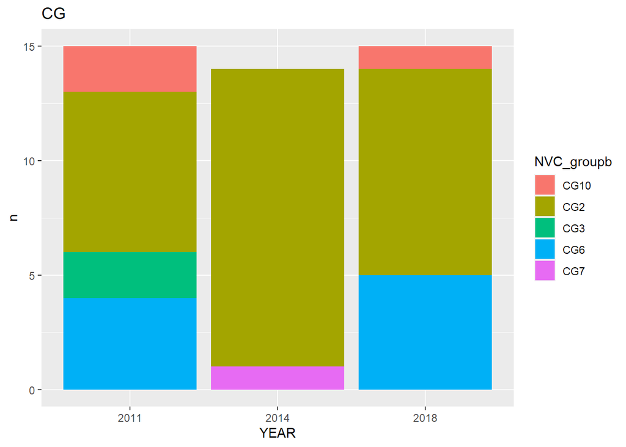

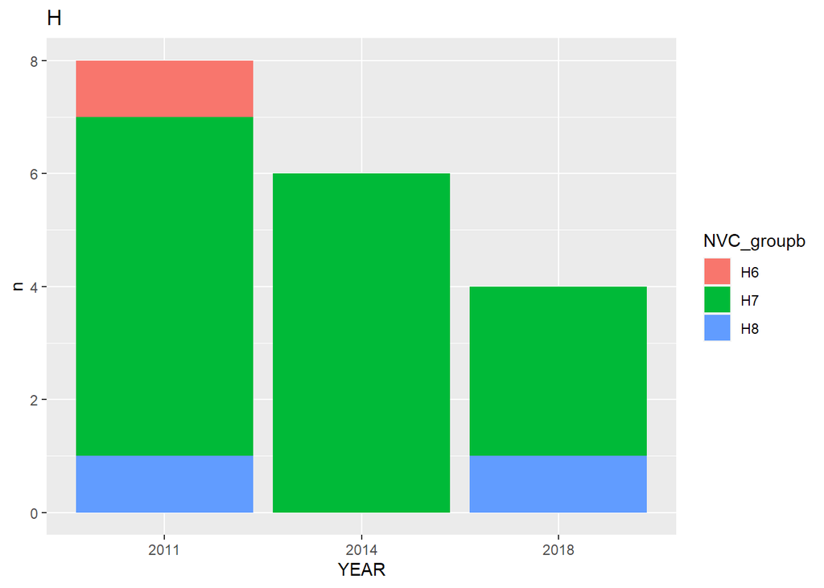

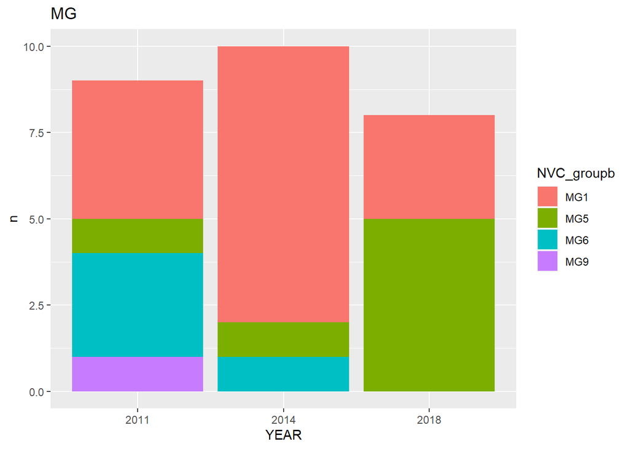

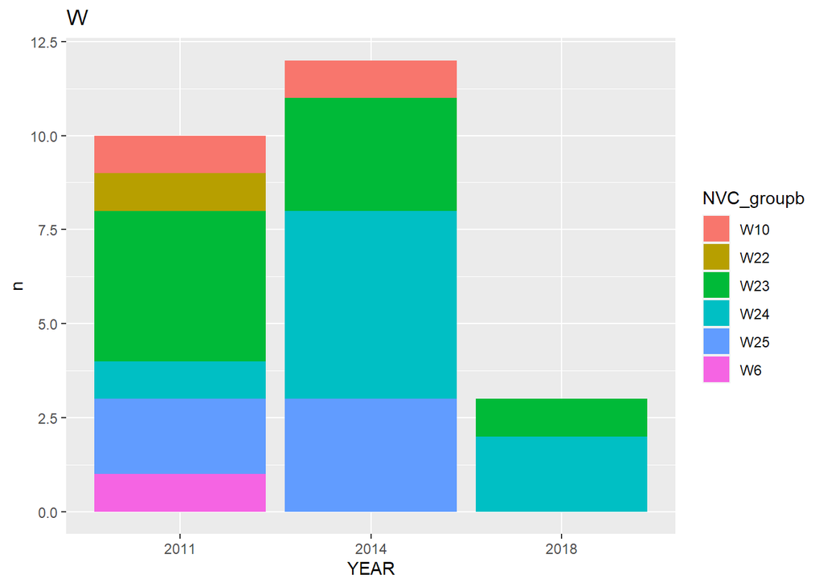

The calcaerous grassland plot could be interesting. There seems to be an increase in good quality CG2 habitat. Lets see if this trend plays out in the rest of the data.

# Describing the species richness and diversity

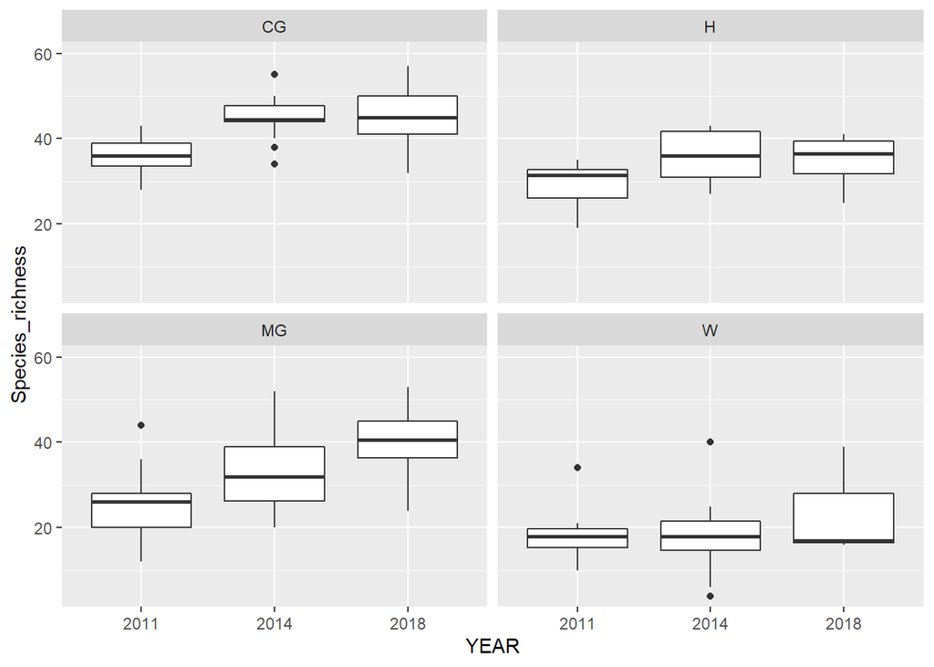

This shows the change in species richness by year, separated by the NVC habitat. This could instead easily be separated by the BAP broad habitat. We can see different trends in the different habitats here. It could be that on particular sites, only certin habitats are of interest. In this case, Lullington is important for its chalk grassland and heath so we could potentially remove the other habitats.

[interactive chart not shown]

This figure shows the habitat by colour and species richness by circle radius. This particular figure is of the most recent 2018 survey. We can include previous surveys in there as well.

We can see that there are a lot of different habitats which might make this a little hard to read. I can only inlcude plots from important habitats, or we can use BAP broad to classify instead of NVC

[interactive chart not shown]

This might be a bit more informative. We can see here how important the work Sarah is doing to fill in the BAP broad habitat classifications is.

[interactive chart not shown]

This shows the change in the last survey. The most striking thing to me here is the change on the east side of the site. There might only be a slight decrease in richness here but I know that this part of the site is supposed to be the best quality chalk grassland. In contrast, the heathland in the centre of the plot seems to be increaseing in species richness.

# Ellenberg and grimes

This section will be to see how ellenberg and grimes scores have changed and if there is a spatial relationship to the change. We can remove these difures for any particular score if there is no change and we can remove just the map figures if the change is not spatially related

### Fertility change by year

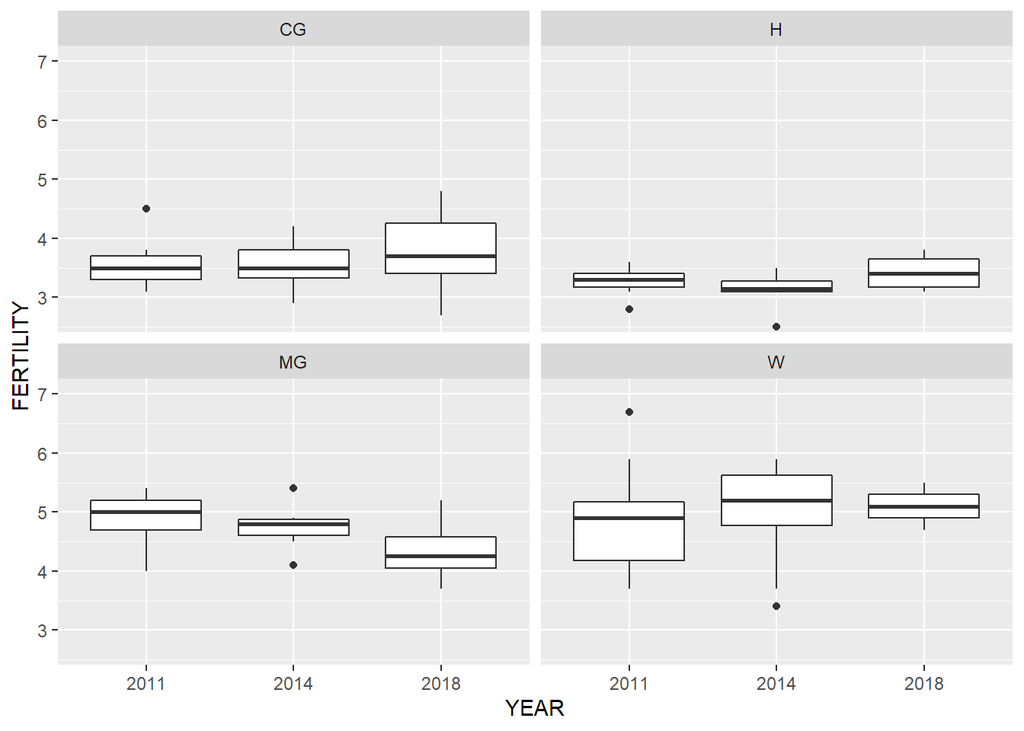

Another example where reducing the number of habitats might be useful.

### Fertility across the site

[interactive chart not shown]

This figure shows there is a slight spatial relationship to fertility across the site. It might be interesting to the site manager. We can see there that the west side of the site is much more fertile and so might not be considerred as important when deciding which areas of the site to prioritise management as it has much less potential. (Of course the site manager might think otherwise but eitherway this plot seems really useful to them).

### Fertility change across the site

[interactive chart not shown]

[interactive chart not shown]

### Litter and bare ground change by year

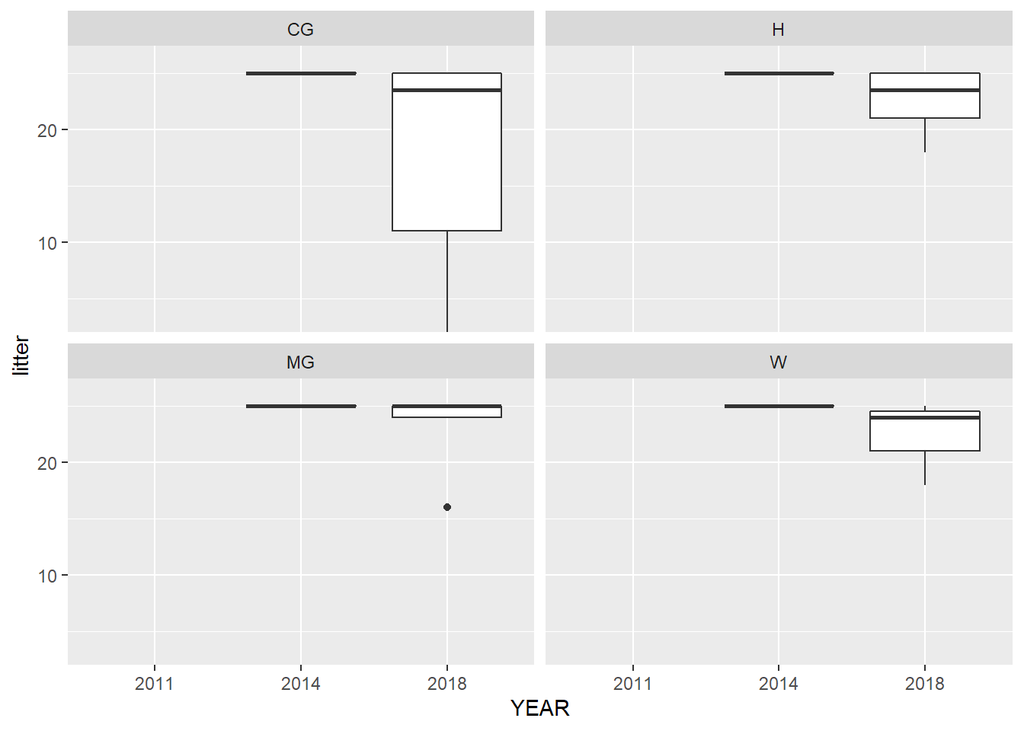

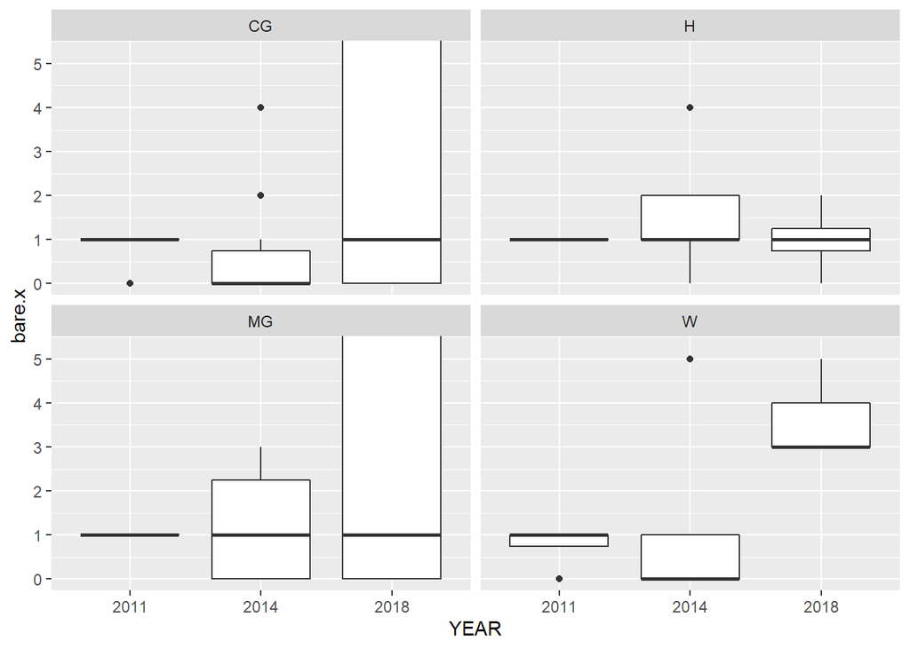

These are probaby two features that could be displayed side by side so I will make a figure for that for each habitat. However, we can see here that the litter was not particularly wel recorded in the early surveys at Lullington so in this case we might omit this figure.

Here are a list of the other features we can display

```
##  [1] "PLOT_ID"           "Species_richness"  "Species_diversity"
##  [4] "SITECODE"          "YEAR"              "EASTINGS"
##  [7] "NORTHINGS"         "BAP_BROAD"         "BAP_PRIORITY"
## [10] "NVC_FIRST"         "LIGHT"             "WETNESS"
## [13] "PH"                "FERTILITY"         "COMPETITION"
## [16] "STRESS"            "RUDERALS"          "NVC_group"
## [19] "NVC_groupb"        "NVC_groupc"        "MEAN_HEIGHT"
## [22] "STD_HEIGHT"        "bare.soil"         "litter"
## [25] "bare.x"            "open.water"        "bare.rock"
## [28] "bare.peat"         "dead.wood"         "bare.soil.sand"
## [31] "leaf.litter"       "exposed.stone"     "exposed.rock"
## [34] "bare.ground"       "deadwood"          "glacial.pebbles"
## [37] "bare.earth"        "coords.easting"    "coords.northing"
```